# ÉTUDE GÉNÉRALISÉE DE LA SOUS-NUTRITION DANS LE MONDE

## II. Pertes alimentaires

### *II.1. Potentiel alimentaire pouvant être libéré*

Imaginons maintenant que nous distribuions les pertes alimentaires de façon équitablement répartie à l'ensemble de la population mondiale en sous-nutrition. Si l'on estime du graphique précédent que **47,44% de la disponibilité alimentaire totale peut nourrir 89,54% de la population mondiale**, il suffit d'un simple calcul mathématique pour voir ce que les **5,54% de pertes auraient pu rassasier**.

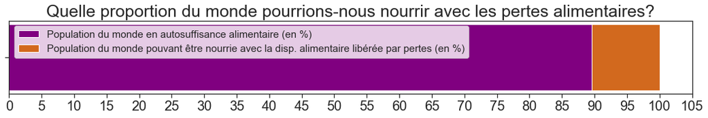

```
On nourrirait donc 100.0% du monde si les pertes alimentaires étaient consommées équitablement par la
population en sous-nutrition
```

```python
PT=PRCN*5.54/47.44 # Pourcentage de la population mondiale pouvant être nourrie par l'ensemble des pertes alimentaires.
PT=round(PT, 2)

barre_nutritive(PRCN, PT, "purple", "monde", "pertes", 106)
plt.title("Quelle proportion du monde pourrions-nous nourrir avec les pertes alimentaires?", fontsize=25)
plt.savefig("data/projet_8/graphiques/4.II.1.png") ; plt.show()

print("On nourrirait donc {}% du monde si les pertes alimentaires étaient consommées équitablement par la".format(PRCN+PT))
print("population en sous-nutrition")
```

Il nous faut admettre que ce score rond de 100%, fruit de notre estimation, est un hasard. En considérant donc la qualité des paramètres de notre estimation, on peut donc admettre que les pertes libererait de justesse le monde de la faim! Nous allons maintenant repérer les zones géographiques où l'on peut relever des pertes importantes.

### *II.2. Ciblage géographique*

Repérons donc d'abord les pays dont le pourcentage des pertes alimentaires est le plus élevé selon leurs clusters définis à la mission 3. Ce premier graphique ne présentera donc pas de résultats pour ce qui est des pertes de quantités alimentaires.

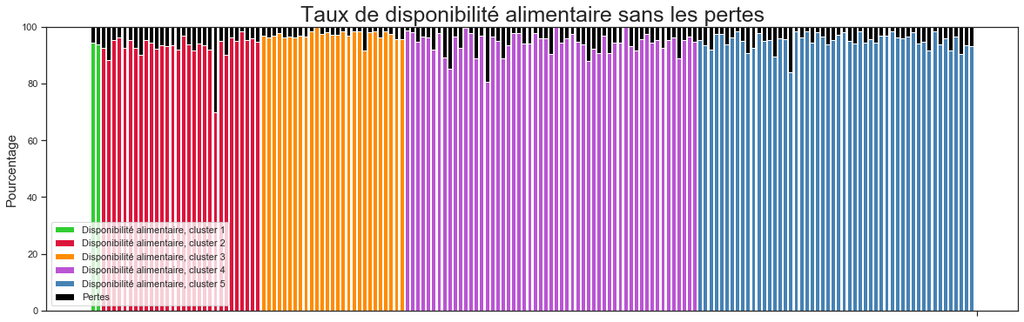

```python
plt.figure(figsize=(20, 6))
w1, w2, w3, w4, w5 = world_cluster(1), world_cluster(2), world_cluster(3), world_cluster(4), world_cluster(5)
c=0
for data in [w1, w2, w3, w4, w5]:
    plt.bar(data.index, data["food_per"]+data["feed_per"]+data["other_uses_per"],
            label="Disponibilité alimentaire, cluster %s" %(c+1), color=palette[c])
    c+=1
plt.bar(world.index, world["waste_per"], bottom=world["food_per"]+world["feed_per"]+world["other_uses_per"],
        label="Pertes", color="black")
plt.xticks("") ; plt.ylabel("Pourcentage", fontsize=15) ;
plt.title("Taux de disponibilité alimentaire sans les pertes", fontsize=25) ; plt.legend()
plt.savefig("data/projet_8/graphiques/4.II.2a.png") ; plt.show()
```

Remarquons que les pertes sont plus importantes dans les pays des clusters 2 et 4. En revanche, ces deux derniers clusters disposantes des quantités alimentaires les plus faibles, on peut supposer que leurs pertes ne sont pas les plus élevées en terme de quantités. C'est donc ce que nous allons maintenant observer.

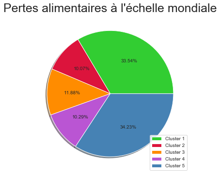

```python
plt.figure(figsize=(6, 6))
world_pie("waste")
plt.title("Pertes alimentaires à l'échelle mondiale", fontsize=(25))
plt.savefig("data/projet_8/graphiques/4.II.2b.png") ; plt.show()
```

Les pertes alimentaires semblent équivalentes entre les pays pauvres et les pays riches en regardant les résultats pour les clusters 2, 3 et 4. En clair, la quantité alimentaire des pertes ne semble pas être corrélée au PIB du pays. La Chine et l'Inde sont à l'origine d'environ 1/3 des pertes alimentaires alors qu'ils présentent environ 42,89% de la sous-nutrition mondiale. Nous observerons donc ce que ces pertes pourraient combler au sein de ce cluster. L'observation de ce graphique nous poussera également à nous concentrer sur le cluster 5. Ce graphique montre que plus du tiers de l'ensemble des pertes alimentaires proviennent du cluster 5, alors que ce groupe de pays représentent 22,64% de la population mondiale.

### *II.3. Des pertes à l'origine de la sous-nutrition locale dans certains pays*

Nous allons maintenant regarder la proportion de la population que l'on pourrait nourrir dans les pays des clusters 1 et 5 si les pertes étaient réutilisées pour de la nourriture et équitablement distribuées aux habitants en sous-nutrition.

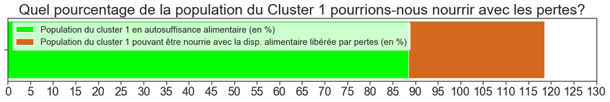

```
________________________________________________________________________________________________________________________
```

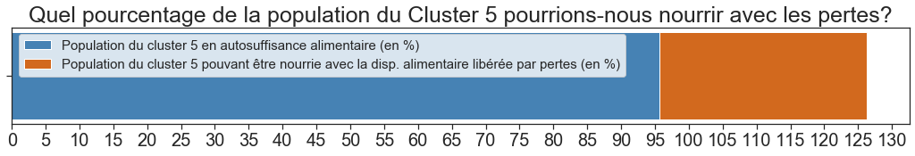

```python
# Cluster 1:
up1=100*w1["nourished"].sum()/w1["population"].sum()
np1=33.54*PRCN/100

barre_nutritive(up1, np1, "lime", "cluster 1", "pertes", 131)
plt.title("Quel pourcentage de la population du Cluster 1 pourrions-nous nourrir avec les pertes?", fontsize=25)
plt.savefig("data/projet_8/graphiques/4.II.3a.png") ; plt.show()

print("_"*120)

# Cluster 5:
up5=100*w5["nourished"].sum()/w5["population"].sum()
np5=34.23*PRCN/100

barre_nutritive(up5, np5, "steelblue", "cluster 5", "pertes", 131)
plt.title("Quel pourcentage de la population du Cluster 5 pourrions-nous nourrir avec les pertes?", fontsize=25)
plt.savefig("data/projet_8/graphiques/4.II.3b.png") ; plt.show()
```

En dépit de sa population exhorbitante, on peut considérer les résultats comme fragiles pour le cluster 1. En revanche, les pertes locales pourraient combler l'Inde et la Chine de la famine si correctement distribuées. Ce mouvement paraissant difficilement réalisable à bien pour ces deux pays, on peut admettre que la gestion des pertes alimentaires contribueraient à venir à bout de la famine mais ne suffirait pas. C'est pourquoi nous maintenons notre conclusion à la mission 3, stipulant qu'une aide extérieure serait nécessaire pour le Cluster 1.

Nous avons vu que les pays du Cluster 5 disposaient tous d'un potentiel alimentaire autosuffisant (cf. mission 3), et nous avons supposé que la sous-nutrition (assez faible mais présente) était liée aux conditions politiques de ces pays pour ce qui est de la gestion alimentaire. Ces résultats nous confirment cette supposition. Sans les pertes, le cluster 5 serait nourrit à plus de 120%. Ce sera donc bien les politiques de gestion alimentaire qui seront à revoir au sein de ces pays pour y venir à bout de la sous-nutrition.

## III. Autres libérations alimentaires

### *III.1. Nourriture pour animaux*

Bien entendu, nous n'allons pas arrêter de nourrir les animaux (ce serait horrible...), mais à l'instar de la production de nourriture pour l'homme, la gestion de la production de nourriture pour l'animal peut se discuter. Prenons, par exemple, les États-Unis, et concentrons-nous sur les quantités produites, cette fois-ci, et comparons-les aux quantités alimentaires produites pour l'homme au Brésil.

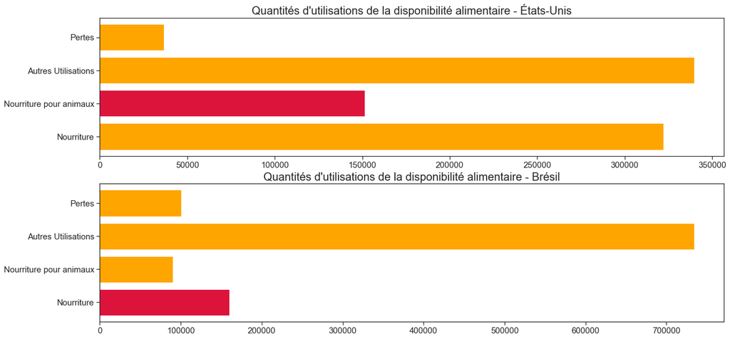

```python
usa=world.loc[world.index=="États-Unis"]
bre=world.loc[world.index=="Brésil"]
P=["États-Unis", "Brésil"] ; k=0

plt.figure(figsize=(20, 10))

for data in (usa, bre):
    a, b = data["food"].values[0], data["feed"].values[0]
    c, d = data["other_uses"].values[0], data["waste"].values[0]
    L=[b, a] ; U=["Nourriture pour animaux", "Nourriture"]
    plt.subplot(2, 1, k+1)
    plt.barh(["Nourriture", "Nourriture pour animaux", "Autres Utilisations", "Pertes"], [a, b, c, d], color="orange")
    plt.barh(U[k], L[k], color="crimson")
    plt.title("Quantités d'utilisations de la disponibilité alimentaire - {}".format(P[k]), fontsize=20)
    plt.yticks(fontsize=15) ; plt.xticks(fontsize=15) ; k+=1

plt.savefig("data/projet_8/graphiques/4.III.1a.png") ; plt.show()
```

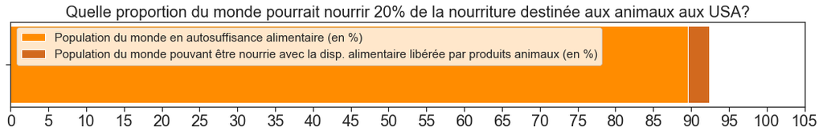

```python
ani=0.2*100*c/FQ
barre_nutritive(PRCN, ani, "darkorange", "monde", "produits animaux", 106)
plt.title("Quelle proportion du monde pourrait nourrir 20% de la nourriture destinée aux animaux aux USA?", fontsize=20)
plt.savefig("data/projet_8/graphiques/4.III.1b.png") ; plt.show()
```

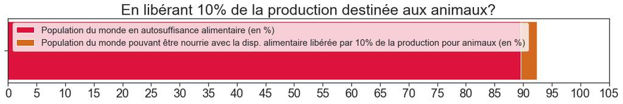

```python
NA1P=10*world["feed"].sum()/FQ
barre_nutritive(PRCN, NA1P, "crimson", "monde", "10% de la production pour animaux", 106)
plt.title("En libérant 10% de la production destinée aux animaux?", fontsize=25)
plt.savefig("data/projet_8/graphiques/4.III.1c.png") ; plt.show()
```

L'idée reste à creuser mais il est intéressant de constater que seulement 10% de la production agricole destinée aux animaux suffirait à libérer 2,5% de la population en sous-nutrition de façon générale.

### *III.2. Autres utilisations alimentaires*

Comme pour la partie précédente, voyons ce que 10% de ces "autres utilisations" pourrait libérer comme potentiel alimentaire.

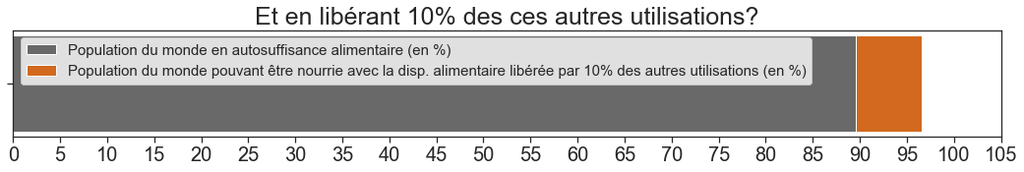

```python
NA1P=10*world["other_uses"].sum()/FQ
barre_nutritive(PRCN, NA1P, "dimgrey", "monde", "10% des autres utilisations", 106)
plt.title("Et en libérant 10% des ces autres utilisations?", fontsize=25)
plt.savefig("data/projet_8/graphiques/4.III.2.png") ; plt.show()
```

Ces résultats montrent que si l'on montait à 20% de réorientation de ces autres utilisations vers de la nourriture pour l'homme, pourrait libérer de quoi sauver le monde de la faim, également.

```python
world.loc[world.index=="Brésil"]
```

| country | cluster | population | undernourished | und_percentage | potentiel | domestic_supply | food_per | feed_per | other_uses_per | waste_per | nourished | food | feed | waste | other_uses | exportation |
| --- | --- | --- | --- | --- | --- | --- | --- | --- | --- | --- | --- | --- | --- | --- | --- | --- |
| Brésil | 5 | 207833820.0 | 10391691.0 | 5.0 | 144.444444 | 1086032.0 | 14.744777 | 8.333364 | 67.630051 | 9.291807 | 197442129.0 | 160133.0 | 90503.0 | 100912.0 | 734484.0 | 12.958589 |

### *III.3. Taux d'exportations*

Enfin, nous exploiterons un dernier critère contribuant à la sous-nutrition dans les pays les plus pauvres qui est le taux d'exportations. Nous avons vu que les pays les plus riches présentaient une disponibilité alimentaire excédentaire, à l'inverse des pays dans le besoin qui, eux, ne disposent pas des ressources nécessaires pour nourrir leur population. Nous verrons cependant que dans certains pays, une réorganisation alimentaire locale permettrait de subvenir aux besoins des habitants sous-alimentés.

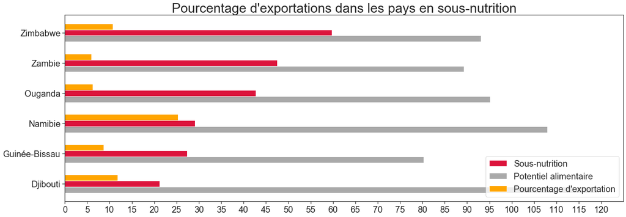

```python
ba=world.loc[world.index.isin(["Guinée-Bissau", "Zambie", "Ouganda", "Namibie", "Djibouti", "Zimbabwe"])]

plt.figure(figsize=(20, 7))
x, y1, y2, y3= range(len(ba)), ba["und_percentage"], ba["potentiel"], ba["exportation"]

plt.barh(x, y1, height=0.2, label="Sous-nutrition", color="crimson")
plt.barh([i-0.2 for i in x], y2,  height=0.2, label="Potentiel alimentaire", color="darkgrey")
plt.barh([i+0.2 for i in x] , y3,  height=0.2, label="Pourcentage d'exportation", color="orange")

plt.xticks(range(0, 121, 5), fontsize=20)
plt.yticks(fontsize=20) ; plt.legend(fontsize=20, loc="lower right")
plt.yticks(range(len(ba)), [i for i in ba.index])
plt.title("Pourcentage d'exportations dans les pays en sous-nutrition", fontsize=30) ; plt.tight_layout()
plt.savefig("data/projet_8/graphiques/4.III.3.png") ; plt.show()
```

Nous avons détecté des pays en sous-nutrition critique où les taux d'exportations alimentaires étaient relativement important. En effet, certains chefs d'état semblent privilégier un apport financier au détriment de la rassasion de leur peuple, souffrant pourtant de la famine. Observons que chacun des pays choisis pour mettre cet aspect en avant témoignent d'un potentiel alimentaire insuffisant, ou au mieux extrêmement fragile. Plus de 20% de la population de ces pays est en sous-nutrition, allant même au-delà des 40% pour l'Ouganda, la Zambie et la Zimbabwe. Et nous relevons des taux d'exportations de plus de 5%, allant jusqu'à 25% pour la Namibie. Il est donc important de souligner ces disproportions. Bien que l'on s'en prenne à des dispositifs commerciaux qui dépassent le cadre de ce projet, nos valeurs tendent à prioriser la sassité de l'être humain, avant toute autre oeuvre marchande ou commerciale.

## IV. Conclusion

*La faim dans le monde est un combat perpétuel que nous menons depuis des siècles. La première victoire de l'humanité sur ce fléau est sa capacité à nourrir le monde entier, comme nous avoir pu le voir et rappeler tout au long du projet. Il s'agit maintenant d'utiliser la disponibilité alimentaire mondiale à bon escient. Nous avons vu que certains pays comme l'Algérie, la Roumanie ou encore le Mexique (Cluster 5) relevaient la sous-nutrition malgré un potentiel alimentaire auto-satisfaisant. La politique de gestion alimentaire serait donc à revoir au sein même de ces pays pour faire disparaître la famine. Les relations internationales avec les pays autosuffisants jouent également un rôle clef dans cette lutte. Les exploitations agricoles pour le compte de certaines multinationales ne sont pas suffisamment dirigées vers les peuples en sous-nutrition. Nous pouvons citer l'exemple des transactions foncières au Brésil, où les habitants se voient privés de certaines terres agricoles susceptibles de sauver une partie de la population locale. Nous avons pu voir également lors de la mission 1 une variable peu exploitée par la suite qui est le pourcentage d'exportations de la disponibilité alimentaire, où nous avons vu que certains pays en sous-nutrition comme la Zimbabwe ou l'Ouganda se tournait vers des bénéfices extérieurs liés à l'exportation agricole au détriment de la nurtrition de leur peuple. Enfin, nous mettrons surtout en avant dans cette conclusion la mauvaise répartition de la disponibilité alimentaire mondiale. Des pays comme le Libéria et la République Centrafricaine ne disposent pas de quoi nourrir leur peuple. Nous avons relevé des potentiels alimentaires particulièrement bas dans ces deux derniers pays, pour chacune des deux unités d'énergie. Nous pouvons proposer un plan en trois étapes qui consiterait à orienter les aides alimentaires internationales et humanitaires et vers les pays relevés dans le Cluster 2 ainsi que vers l'Inde en priorité, réorganiser la politique de gestion alimentaire pour la Chine et les pays des Cluster 5 et 4, pour ensuite orienté ces mêmes aides vers le Cluster 4. Ce plan peut paraître ambitieux, mais est réalisable en vertue des données de dispositions alimentaires présentées dans ce projet, et pourrait - espérons-le - enfin mettre un terme à la famine dans les quatre coins du monde.*

*Projet réalisé par Bertrand Delorme, Data Analyst*